# k-means explanation

#### **Intro**

It all began with the fact that I’ve decided to study k-means clustering algorithm. The more resources I read, the more confused . The definition of cluster centers has been stumbling-block. The most accessible explanation was provided by [Wikipedia](https://en.wikipedia.org/wiki/K-means_clustering):

> Assign each observation to the cluster whose mean has the least squared Euclidean distance.

But how does this happen? So I’ve decided to reinvent a wheel and reproduce step by step all stages of the algorithm. As a basis I’ve decided to take an example from the book by Roger D. Peng [Exploratory Data Analysis with R](https://bookdown.org/rdpeng/exdata/k-means-clustering.html).

Because I’m a passionate fan of R I’ve decided to use fantastic package [tydiverse](https://www.tidyverse.org/) to reproduce algorithm and gganimate to visualize result.  
So, let’s begin!

#### **Dataset preparing**

I’ve decided to reproduce dataset that is provided by Roger D.Peng (Figure 12.1: Simulated dataset)

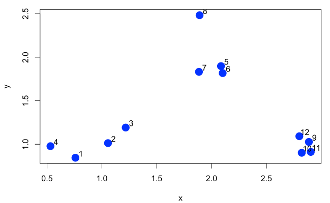

```r
set.seed(1234)
x <- c(0.75, 1.1, 1.25, 0.55, 2.15, 2.17, 1.85, 1.86, 2.87, 2.75, 2.91, 2.71)
y <- c(0.6, 1.0, 1.25, 1.0, 1.9, 1.8, 1.85, 2.5, 1.0, 0.85, 0.86, 1.18)
df_xy <- tibble(x, y)
# Length of dataset
n_xy <- dim(df_xy)[1]
```

Let’s take three clusters for example

```r
Cx = c(1, 1.7, 2.5)
Cy = c(2, 1.0, 1.5)
# Number of clusters define as length of Cx or Cy vectors
n_clust <- length(Cx)
df_cl <- tibble(Cluster = factor(seq(n_clust), ordered = T), Cx, Cy)
```

Next create a dataset with coordinates of observations and coordinates of cluster centers

```r
df_kmeans0 <- bind_cols(df_xy, map_dfr(df_cl, rep, each = length(x) / n_clust))
```

Here’s how all this looks like at the initial stage

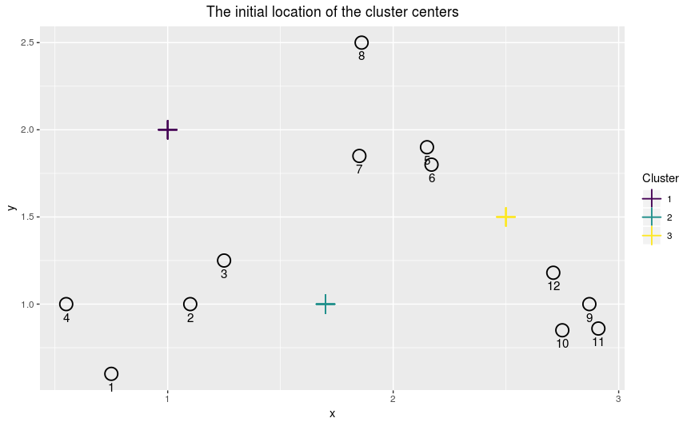

```r
ggplot(df_kmeans0, aes(x, y)) +
  geom_point(shape = 1, size = 5, stroke = 1) +
  geom_text(aes(x, y, label = rownames(df_xy)), vjust = 2.0, size = 4, color = "black") +
  geom_point(aes(Cx, Cy, color = Cluster), shape = 3, size = 5, stroke = 1) +
  labs(title = "The initial location of the cluster centers") +
  theme(plot.title = element_text(hjust = 0.5))
```

Now let’s look what’s happen under the hood of k-means

> Eu_dist<sup>2</sup> = (x<sub>i</sub> - x<sub>c</sub>)<sup>2</sup> + (y<sub>i</sub> - y<sub>c</sub>)<sup>2</sup>

Next, it needs to determine the distance from each point to each cluster. Since we have 12 points and 3 clusters, we get 36 distances. It was the first stumbling-block.

```r
df_dist <- bind_cols(map_dfr(df_xy, rep, n_clust),
                     map_dfr(df_cl, rep, each = n_xy)) %>%
  mutate(Eu_dist = sqrt((.$x - .$Cx)^2 + (.$y - .$Cy)^2))
df_dist
```

| x | y | Cluster | Cx | Cy | Eu_dist |
| --- | --- | --- | --- | --- | --- |
| 0.75 | 0.60 | 1 | 1.0 | 2.0 | 1.4221463 |
| 1.10 | 1.00 | 1 | 1.0 | 2.0 | 1.0049876 |
| 1.25 | 1.25 | 1 | 1.0 | 2.0 | 0.7905694 |
| 0.55 | 1.00 | 1 | 1.0 | 2.0 | 1.0965856 |
| 2.15 | 1.90 | 1 | 1.0 | 2.0 | 1.1543396 |
| 2.17 | 1.80 | 1 | 1.0 | 2.0 | 1.1869709 |
| 1.85 | 1.85 | 1 | 1.0 | 2.0 | 0.8631338 |
| 1.86 | 2.50 | 1 | 1.0 | 2.0 | 0.9947864 |
| 2.87 | 1.00 | 1 | 1.0 | 2.0 | 2.1205895 |
| 2.75 | 0.85 | 1 | 1.0 | 2.0 | 2.0940392 |

[output cut: 26 more lines]

#### **Step.2 Assign each observation to the cluster whose mean has the least squared Euclidean distance**

```r
step2 <- df_dist %>%
  select(-Cx, -Cy) %>%
  spread(Cluster, Eu_dist) %>%
  nest(-x, -y) %>%
  mutate(Eu_dist = map_dbl(.$data, min),
         Cluster = map_dbl(.$data, which.min) %>% factor(., ordered = T)) %>%
  unnest(data) %>%
  arrange(match(x, df_xy$x)) # відновлюємо порядок слідування точок як у вихідному датасеті
step2
```

| x | y | Eu_dist | Cluster | 1 | 2 | 3 |
| --- | --- | --- | --- | --- | --- | --- |
| 0.75 | 0.60 | 1.0307764 | 2 | 1.4221463 | 1.0307764 | 1.9678669 |
| 1.10 | 1.00 | 0.6000000 | 2 | 1.0049876 | 0.6000000 | 1.4866069 |
| 1.25 | 1.25 | 0.5147815 | 2 | 0.7905694 | 0.5147815 | 1.2747549 |
| 0.55 | 1.00 | 1.0965856 | 1 | 1.0965856 | 1.1500000 | 2.0130822 |
| 2.15 | 1.90 | 0.5315073 | 3 | 1.1543396 | 1.0062306 | 0.5315073 |
| 2.17 | 1.80 | 0.4459821 | 3 | 1.1869709 | 0.9278470 | 0.4459821 |
| 1.85 | 1.85 | 0.7382412 | 3 | 0.8631338 | 0.8631338 | 0.7382412 |
| 1.86 | 2.50 | 0.9947864 | 1 | 0.9947864 | 1.5085092 | 1.1872658 |
| 2.87 | 1.00 | 0.6220129 | 3 | 2.1205895 | 1.1700000 | 0.6220129 |
| 2.75 | 0.85 | 0.6964194 | 3 | 2.0940392 | 1.0606602 | 0.6964194 |

[output cut: 2 more lines]

Columns 1-3 represent all (3 in our case) distances of observation to each cluster. We need to choose the minimum value for each observation. They are gathered in Eu_dist column. So, the columns Eu_dist and Cluster demonstrate which observations to which clusters belong. It was the second and the last stumbling-block.

#### **Step 3. Join cluster’s coordinates to previous dataset**

Now it remains to add the coordinates of cluster centers to our previous data set

```r
step2 %>%
  left_join(df_cl, by = 'Cluster') -> step3
step3
```

| x | y | Eu_dist | Cluster | 1 | 2 | 3 | Cx | Cy |
| --- | --- | --- | --- | --- | --- | --- | --- | --- |
| 0.75 | 0.60 | 1.0307764 | 2 | 1.4221463 | 1.0307764 | 1.9678669 | 1.7 | 1.0 |
| 1.10 | 1.00 | 0.6000000 | 2 | 1.0049876 | 0.6000000 | 1.4866069 | 1.7 | 1.0 |
| 1.25 | 1.25 | 0.5147815 | 2 | 0.7905694 | 0.5147815 | 1.2747549 | 1.7 | 1.0 |
| 0.55 | 1.00 | 1.0965856 | 1 | 1.0965856 | 1.1500000 | 2.0130822 | 1.0 | 2.0 |
| 2.15 | 1.90 | 0.5315073 | 3 | 1.1543396 | 1.0062306 | 0.5315073 | 2.5 | 1.5 |
| 2.17 | 1.80 | 0.4459821 | 3 | 1.1869709 | 0.9278470 | 0.4459821 | 2.5 | 1.5 |
| 1.85 | 1.85 | 0.7382412 | 3 | 0.8631338 | 0.8631338 | 0.7382412 | 2.5 | 1.5 |
| 1.86 | 2.50 | 0.9947864 | 1 | 0.9947864 | 1.5085092 | 1.1872658 | 1.0 | 2.0 |
| 2.87 | 1.00 | 0.6220129 | 3 | 2.1205895 | 1.1700000 | 0.6220129 | 2.5 | 1.5 |
| 2.75 | 0.85 | 0.6964194 | 3 | 2.0940392 | 1.0606602 | 0.6964194 | 2.5 | 1.5 |

[output cut: 2 more lines]

Let’s demonstrate result

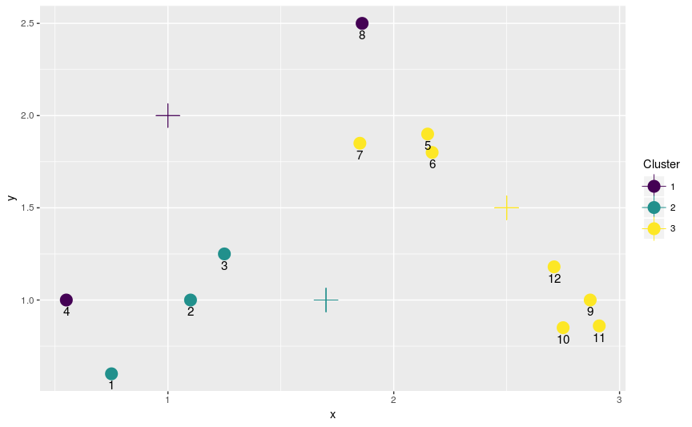

```r
ggplot(step3, aes(x, y, color = Cluster)) +
  geom_point(size = 5) +
  geom_point(aes(x = step3$Cx, y = step3$Cy), shape = 3, size = 7) +
  geom_text(label = rownames(step3), vjust = 1.8, size = 4, color = 'black')
```

#### **Step 4. Recalculation center’s coordinates of new clusters**

```r
step3 %>%
  select(-num_range("", 1:n_clust)) %>%
  group_by(Cluster) %>%
  mutate(Cx2 = mean(x),
         Cy2 = mean(y)) -> step4
step4
```

| x | y | Eu_dist | Cluster | Cx | Cy | Cx2 | Cy2 |
| --- | --- | --- | --- | --- | --- | --- | --- |
| 0.75 | 0.60 | 1.0307764 | 2 | 1.7 | 1.0 | 1.033333 | 0.950000 |
| 1.10 | 1.00 | 0.6000000 | 2 | 1.7 | 1.0 | 1.033333 | 0.950000 |
| 1.25 | 1.25 | 0.5147815 | 2 | 1.7 | 1.0 | 1.033333 | 0.950000 |
| 0.55 | 1.00 | 1.0965856 | 1 | 1.0 | 2.0 | 1.205000 | 1.750000 |
| 2.15 | 1.90 | 0.5315073 | 3 | 2.5 | 1.5 | 2.487143 | 1.348571 |
| 2.17 | 1.80 | 0.4459821 | 3 | 2.5 | 1.5 | 2.487143 | 1.348571 |
| 1.85 | 1.85 | 0.7382412 | 3 | 2.5 | 1.5 | 2.487143 | 1.348571 |
| 1.86 | 2.50 | 0.9947864 | 1 | 1.0 | 2.0 | 1.205000 | 1.750000 |
| 2.87 | 1.00 | 0.6220129 | 3 | 2.5 | 1.5 | 2.487143 | 1.348571 |
| 2.75 | 0.85 | 0.6964194 | 3 | 2.5 | 1.5 | 2.487143 | 1.348571 |

[output cut: 2 more lines]

Let’s look at new clusters (smaller size - are initial values)

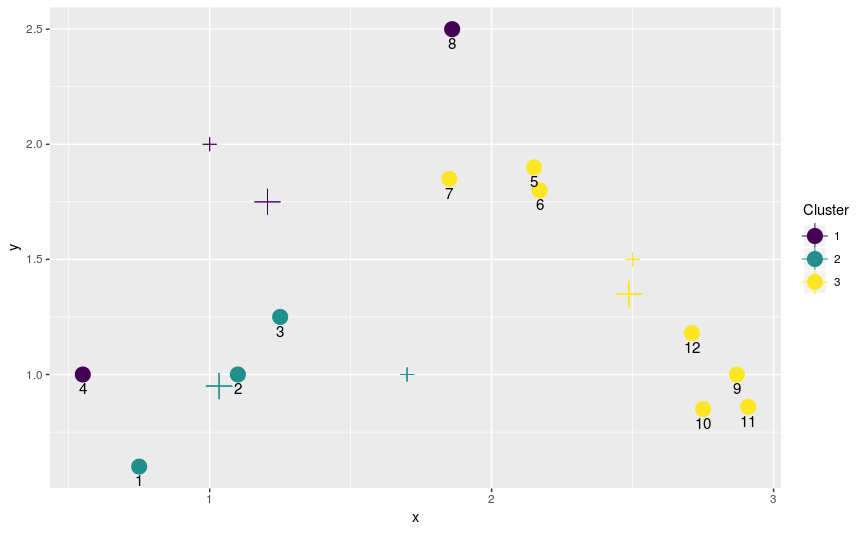

```r
step4 %>%
  ggplot(aes(x, y, color = Cluster)) +
    geom_point(size = 5) +
    geom_point(aes(x = step4$Cx, y = step4$Cy), shape = 3, size = 3) +
    geom_point(aes(x = step4$Cx2, y = step4$Cy2), shape = 3, size = 6) +
    geom_text(aes(label = rownames(step4)), vjust = 1.8, size = 4, color = 'black')
```

Put our dataset with new clusters into “canonical” form

```r
step4 %>%
  select(Cluster, Cx2, Cy2) %>%
  group_by(Cluster) %>%
  unique(.) %>%
  arrange(Cluster) -> new_iteration
new_iteration
```

| Cluster | Cx2 | Cy2 |
| --- | --- | --- |
| 1 | 1.205000 | 1.750000 |
| 2 | 1.033333 | 0.950000 |
| 3 | 2.487143 | 1.348571 |

Next - repeat iteration from step 1 and so on, but for this purpose it needs to have something like recursive function. And this is stated further. At this stage, I’ve became aware of the principle of k-means, but I wanted to see the results for several iterations and compare the results with a regular algorithm - the kmeans() function.